# (Ford GoBike System)

## Preliminary Wrangling

> The data set is called Fordgobike, This data set includes information about individual rides made in a bike-sharing system covering the greater San Francisco Bay area, and represents trips taken by members of the service for month of February of 2019

> The Features:
> - duration_sec: duration per second
> - start_time: the time that the trip started at
> - end_time: the time that the trip ended at
> - start_station_id
> - start_station_name
> - start_station_latitude
> - start_station_longitude
> - end_station_id
> - end_station_name
> - end_station_latitude
> - end_station_longitude
> - bike_id
> - user_type
> - member_birth_year
> - member_gender
> - bike_share_for_all_trip

```python
# import all packages and set plots to be embedded inline
import numpy as np
import pandas as pd
import matplotlib.pyplot as plt
import seaborn as sb

%matplotlib inline
```

```python
ford_df = pd.read_csv('201902-fordgobike-tripdata.csv')
ford_df.head()
```

|  | duration_sec | start_time | end_time | start_station_id | start_station_name | start_station_latitude | start_station_longitude | end_station_id | end_station_name | end_station_latitude | end_station_longitude | bike_id | user_type | member_birth_year | member_gender | bike_share_for_all_trip |
| --- | --- | --- | --- | --- | --- | --- | --- | --- | --- | --- | --- | --- | --- | --- | --- | --- |
| 0 | 52185 | 2019-02-28 17:32:10.1450 | 2019-03-01 08:01:55.9750 | 21.0 | Montgomery St BART Station (Market St at 2nd St) | 37.789625 | -122.400811 | 13.0 | Commercial St at Montgomery St | 37.794231 | -122.402923 | 4902 | Customer | 1984.0 | Male | No |
| 1 | 42521 | 2019-02-28 18:53:21.7890 | 2019-03-01 06:42:03.0560 | 23.0 | The Embarcadero at Steuart St | 37.791464 | -122.391034 | 81.0 | Berry St at 4th St | 37.775880 | -122.393170 | 2535 | Customer | NaN | NaN | No |
| 2 | 61854 | 2019-02-28 12:13:13.2180 | 2019-03-01 05:24:08.1460 | 86.0 | Market St at Dolores St | 37.769305 | -122.426826 | 3.0 | Powell St BART Station (Market St at 4th St) | 37.786375 | -122.404904 | 5905 | Customer | 1972.0 | Male | No |
| 3 | 36490 | 2019-02-28 17:54:26.0100 | 2019-03-01 04:02:36.8420 | 375.0 | Grove St at Masonic Ave | 37.774836 | -122.446546 | 70.0 | Central Ave at Fell St | 37.773311 | -122.444293 | 6638 | Subscriber | 1989.0 | Other | No |
| 4 | 1585 | 2019-02-28 23:54:18.5490 | 2019-03-01 00:20:44.0740 | 7.0 | Frank H Ogawa Plaza | 37.804562 | -122.271738 | 222.0 | 10th Ave at E 15th St | 37.792714 | -122.248780 | 4898 | Subscriber | 1974.0 | Male | Yes |

```python
ford_df.info()
```

```
<class 'pandas.core.frame.DataFrame'>
RangeIndex: 183412 entries, 0 to 183411
Data columns (total 16 columns):
 #   Column                   Non-Null Count   Dtype
---  ------                   --------------   -----
 0   duration_sec             183412 non-null  int64
 1   start_time               183412 non-null  object
 2   end_time                 183412 non-null  object
 3   start_station_id         183215 non-null  float64
 4   start_station_name       183215 non-null  object
 5   start_station_latitude   183412 non-null  float64
 6   start_station_longitude  183412 non-null  float64
 7   end_station_id           183215 non-null  float64
 8   end_station_name         183215 non-null  object
 9   end_station_latitude     183412 non-null  float64
 10  end_station_longitude    183412 non-null  float64
 11  bike_id                  183412 non-null  int64
 12  user_type                183412 non-null  object
 13  member_birth_year        175147 non-null  float64
 14  member_gender            175147 non-null  object
 15  bike_share_for_all_trip  183412 non-null  object
dtypes: float64(7), int64(2), object(7)
memory usage: 22.4+ MB
```

```python
ford_df.shape
```

```
(183412, 16)
```

### What is the structure of your dataset?

This data set includes information about individual rides made in a bike-sharing system covering the greater San Francisco Bay area.It includes 183412 rows and 16 feature **(duration_sec, start_time, end_time, start_station_id, start_station_name, start_station_latitude, start_station_longitude, end_station_id, end_station_name, end_station_latitude, end_station_longitude, bike_id, user_type, member_birth_year, member_gender, bike_share_for_all_trip).** There are 9 numeric features and 7 categorical features.**

### What is/are the main feature(s) of interest in your dataset?

After looking at the data, the main features of interest are **(start_time, end_time, start_station_name, end_station_name, user_type, member_birth_year)**

### What features in the dataset do you think will help support your investigation into your feature(s) of interest?

The feature that will help me with my investigation are **(duration_sec, member_gender)**

# Assessing and cleaning

```python
#making a copy from the data
clean_df = ford_df.copy()
```

```python
clean_df.describe()
```

|  | duration_sec | start_station_id | start_station_latitude | start_station_longitude | end_station_id | end_station_latitude | end_station_longitude | bike_id | member_birth_year |
| --- | --- | --- | --- | --- | --- | --- | --- | --- | --- |
| count | 183412.000000 | 183215.000000 | 183412.000000 | 183412.000000 | 183215.000000 | 183412.000000 | 183412.000000 | 183412.000000 | 175147.000000 |
| mean | 726.078435 | 138.590427 | 37.771223 | -122.352664 | 136.249123 | 37.771427 | -122.352250 | 4472.906375 | 1984.806437 |
| std | 1794.389780 | 111.778864 | 0.099581 | 0.117097 | 111.515131 | 0.099490 | 0.116673 | 1664.383394 | 10.116689 |
| min | 61.000000 | 3.000000 | 37.317298 | -122.453704 | 3.000000 | 37.317298 | -122.453704 | 11.000000 | 1878.000000 |
| 25% | 325.000000 | 47.000000 | 37.770083 | -122.412408 | 44.000000 | 37.770407 | -122.411726 | 3777.000000 | 1980.000000 |
| 50% | 514.000000 | 104.000000 | 37.780760 | -122.398285 | 100.000000 | 37.781010 | -122.398279 | 4958.000000 | 1987.000000 |
| 75% | 796.000000 | 239.000000 | 37.797280 | -122.286533 | 235.000000 | 37.797320 | -122.288045 | 5502.000000 | 1992.000000 |
| max | 85444.000000 | 398.000000 | 37.880222 | -121.874119 | 398.000000 | 37.880222 | -121.874119 | 6645.000000 | 2001.000000 |

```python
#checking the null values
clean_df.isnull().sum()
```

```
duration_sec                  0
start_time                    0
end_time                      0
start_station_id            197
start_station_name          197
start_station_latitude        0
start_station_longitude       0
end_station_id              197
end_station_name            197
end_station_latitude          0
end_station_longitude         0
bike_id                       0
user_type                     0
member_birth_year          8265
member_gender              8265
bike_share_for_all_trip       0
dtype: int64
```

```python
#deleting the null values
clean_df = clean_df.dropna()
```

```python
clean_df.isnull().sum()
```

```
duration_sec               0
start_time                 0
end_time                   0
start_station_id           0
start_station_name         0
start_station_latitude     0
start_station_longitude    0
end_station_id             0
end_station_name           0
end_station_latitude       0
end_station_longitude      0
bike_id                    0
user_type                  0
member_birth_year          0
member_gender              0
bike_share_for_all_trip    0
dtype: int64
```

```python
#dropping some unuseful columns
clean_df = clean_df.drop(['start_station_latitude','start_station_longitude', 'end_station_latitude', 'end_station_longitude'], axis = 1)
```

```python
clean_df.info()
```

```
<class 'pandas.core.frame.DataFrame'>
Int64Index: 174952 entries, 0 to 183411
Data columns (total 12 columns):
 #   Column                   Non-Null Count   Dtype
---  ------                   --------------   -----
 0   duration_sec             174952 non-null  int64
 1   start_time               174952 non-null  object
 2   end_time                 174952 non-null  object
 3   start_station_id         174952 non-null  float64
 4   start_station_name       174952 non-null  object
 5   end_station_id           174952 non-null  float64
 6   end_station_name         174952 non-null  object
 7   bike_id                  174952 non-null  int64
 8   user_type                174952 non-null  object
 9   member_birth_year        174952 non-null  float64
 10  member_gender            174952 non-null  object
 11  bike_share_for_all_trip  174952 non-null  object
dtypes: float64(3), int64(2), object(7)
memory usage: 17.4+ MB
```

```python
#converting the start time to datetime
clean_df['start_time'] = pd.to_datetime(clean_df['start_time'])
```

```python
#converting the end time to datetime
clean_df['end_time'] = pd.to_datetime(clean_df['end_time'])
```

```python
clean_df.info()
```

```
<class 'pandas.core.frame.DataFrame'>
Int64Index: 174952 entries, 0 to 183411
Data columns (total 12 columns):
 #   Column                   Non-Null Count   Dtype
---  ------                   --------------   -----
 0   duration_sec             174952 non-null  int64
 1   start_time               174952 non-null  datetime64[ns]
 2   end_time                 174952 non-null  datetime64[ns]
 3   start_station_id         174952 non-null  float64
 4   start_station_name       174952 non-null  object
 5   end_station_id           174952 non-null  float64
 6   end_station_name         174952 non-null  object
 7   bike_id                  174952 non-null  int64
 8   user_type                174952 non-null  object
 9   member_birth_year        174952 non-null  float64
 10  member_gender            174952 non-null  object
 11  bike_share_for_all_trip  174952 non-null  object
dtypes: datetime64[ns](2), float64(3), int64(2), object(5)
memory usage: 17.4+ MB
```

```python
#checking the start station unique values
clean_df.start_station_name.value_counts()
```

```
Market St at 10th St                                         3649
San Francisco Caltrain Station 2  (Townsend St at 4th St)    3408
Berry St at 4th St                                           2952
Montgomery St BART Station (Market St at 2nd St)             2711
Powell St BART Station (Market St at 4th St)                 2620
                                                             ...
Willow St at Vine St                                            9
Parker Ave at McAllister St                                     7
21st Ave at International Blvd                                  4
Palm St at Willow St                                            3
16th St Depot                                                   2
Name: start_station_name, Length: 329, dtype: int64
```

```python
#calculating the age of the users
clean_df['Age'] = 2021 - clean_df['member_birth_year']
```

```python
clean_df = clean_df.drop(['member_birth_year'], axis = 1)
```

```python
clean_df.describe()
```

|  | duration_sec | start_station_id | end_station_id | bike_id | Age |
| --- | --- | --- | --- | --- | --- |
| count | 174952.000000 | 174952.000000 | 174952.000000 | 174952.000000 | 174952.000000 |
| mean | 704.002744 | 139.002126 | 136.604486 | 4482.587555 | 36.196865 |
| std | 1642.204905 | 111.648819 | 111.335635 | 1659.195937 | 10.118731 |
| min | 61.000000 | 3.000000 | 3.000000 | 11.000000 | 20.000000 |
| 25% | 323.000000 | 47.000000 | 44.000000 | 3799.000000 | 29.000000 |
| 50% | 510.000000 | 104.000000 | 101.000000 | 4960.000000 | 34.000000 |
| 75% | 789.000000 | 239.000000 | 238.000000 | 5505.000000 | 41.000000 |
| max | 84548.000000 | 398.000000 | 398.000000 | 6645.000000 | 143.000000 |

```python
clean_df.head()
```

|  | duration_sec | start_time | end_time | start_station_id | start_station_name | end_station_id | end_station_name | bike_id | user_type | member_gender | bike_share_for_all_trip | Age |
| --- | --- | --- | --- | --- | --- | --- | --- | --- | --- | --- | --- | --- |
| 0 | 52185 | 2019-02-28 17:32:10.145 | 2019-03-01 08:01:55.975 | 21.0 | Montgomery St BART Station (Market St at 2nd St) | 13.0 | Commercial St at Montgomery St | 4902 | Customer | Male | No | 37.0 |
| 2 | 61854 | 2019-02-28 12:13:13.218 | 2019-03-01 05:24:08.146 | 86.0 | Market St at Dolores St | 3.0 | Powell St BART Station (Market St at 4th St) | 5905 | Customer | Male | No | 49.0 |
| 3 | 36490 | 2019-02-28 17:54:26.010 | 2019-03-01 04:02:36.842 | 375.0 | Grove St at Masonic Ave | 70.0 | Central Ave at Fell St | 6638 | Subscriber | Other | No | 32.0 |
| 4 | 1585 | 2019-02-28 23:54:18.549 | 2019-03-01 00:20:44.074 | 7.0 | Frank H Ogawa Plaza | 222.0 | 10th Ave at E 15th St | 4898 | Subscriber | Male | Yes | 47.0 |
| 5 | 1793 | 2019-02-28 23:49:58.632 | 2019-03-01 00:19:51.760 | 93.0 | 4th St at Mission Bay Blvd S | 323.0 | Broadway at Kearny | 5200 | Subscriber | Male | No | 62.0 |

```python
#extracting the month from start time
clean_df['start_month'] = clean_df.start_time.dt.strftime('%B')
```

```python
#extracting the day from start time
clean_df['start_day'] = clean_df.start_time.dt.strftime('%A')
```

```python
#extracting the hour from start time
clean_df['start_hour'] = clean_df.start_time.dt.strftime('%H')
```

```python
clean_df.head()
```

|  | duration_sec | start_time | end_time | start_station_id | start_station_name | end_station_id | end_station_name | bike_id | user_type | member_gender | bike_share_for_all_trip | Age | start_month | start_day | start_hour |
| --- | --- | --- | --- | --- | --- | --- | --- | --- | --- | --- | --- | --- | --- | --- | --- |
| 0 | 52185 | 2019-02-28 17:32:10.145 | 2019-03-01 08:01:55.975 | 21.0 | Montgomery St BART Station (Market St at 2nd St) | 13.0 | Commercial St at Montgomery St | 4902 | Customer | Male | No | 37.0 | February | Thursday | 17 |
| 2 | 61854 | 2019-02-28 12:13:13.218 | 2019-03-01 05:24:08.146 | 86.0 | Market St at Dolores St | 3.0 | Powell St BART Station (Market St at 4th St) | 5905 | Customer | Male | No | 49.0 | February | Thursday | 12 |
| 3 | 36490 | 2019-02-28 17:54:26.010 | 2019-03-01 04:02:36.842 | 375.0 | Grove St at Masonic Ave | 70.0 | Central Ave at Fell St | 6638 | Subscriber | Other | No | 32.0 | February | Thursday | 17 |
| 4 | 1585 | 2019-02-28 23:54:18.549 | 2019-03-01 00:20:44.074 | 7.0 | Frank H Ogawa Plaza | 222.0 | 10th Ave at E 15th St | 4898 | Subscriber | Male | Yes | 47.0 | February | Thursday | 23 |
| 5 | 1793 | 2019-02-28 23:49:58.632 | 2019-03-01 00:19:51.760 | 93.0 | 4th St at Mission Bay Blvd S | 323.0 | Broadway at Kearny | 5200 | Subscriber | Male | No | 62.0 | February | Thursday | 23 |

```python
#found that the data set has been collected in february only
clean_df.start_month.value_counts()
```

```
February    174952
Name: start_month, dtype: int64
```

```python
clean_df.info()
```

```
<class 'pandas.core.frame.DataFrame'>
Int64Index: 174952 entries, 0 to 183411
Data columns (total 15 columns):
 #   Column                   Non-Null Count   Dtype
---  ------                   --------------   -----
 0   duration_sec             174952 non-null  int64
 1   start_time               174952 non-null  datetime64[ns]
 2   end_time                 174952 non-null  datetime64[ns]
 3   start_station_id         174952 non-null  float64
 4   start_station_name       174952 non-null  object
 5   end_station_id           174952 non-null  float64
 6   end_station_name         174952 non-null  object
 7   bike_id                  174952 non-null  int64
 8   user_type                174952 non-null  object
 9   member_gender            174952 non-null  object
 10  bike_share_for_all_trip  174952 non-null  object
 11  Age                      174952 non-null  float64
 12  start_month              174952 non-null  object
 13  start_day                174952 non-null  object
 14  start_hour               174952 non-null  object
dtypes: datetime64[ns](2), float64(3), int64(2), object(8)
memory usage: 21.4+ MB
```

```python
clean_df.describe()
```

|  | duration_sec | start_station_id | end_station_id | bike_id | Age |
| --- | --- | --- | --- | --- | --- |
| count | 174952.000000 | 174952.000000 | 174952.000000 | 174952.000000 | 174952.000000 |
| mean | 704.002744 | 139.002126 | 136.604486 | 4482.587555 | 36.196865 |
| std | 1642.204905 | 111.648819 | 111.335635 | 1659.195937 | 10.118731 |
| min | 61.000000 | 3.000000 | 3.000000 | 11.000000 | 20.000000 |
| 25% | 323.000000 | 47.000000 | 44.000000 | 3799.000000 | 29.000000 |
| 50% | 510.000000 | 104.000000 | 101.000000 | 4960.000000 | 34.000000 |
| 75% | 789.000000 | 239.000000 | 238.000000 | 5505.000000 | 41.000000 |
| max | 84548.000000 | 398.000000 | 398.000000 | 6645.000000 | 143.000000 |

## Univariate Exploration

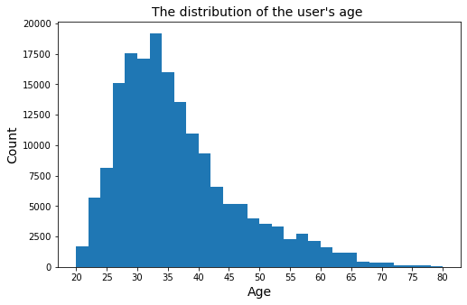

```python
#The distribution of the user's age
plt.figure(figsize = [8, 5])
bins = np.arange(20, 80+2,2)
plt.hist(data = clean_df, x = 'Age', bins = bins, color='#1f77b4');
plt.xticks([20,25,30,35,40,45,50,55,60,65,70,75,80]);
plt.xlabel('Age', fontsize=14);
plt.ylabel('Count', fontsize=14);
plt.title("The distribution of the user's age ", fontsize=14);
```

> I used the histogram plot to show the distribution of the age of the users, and found that the average age of riders is between 25 to 40 years old

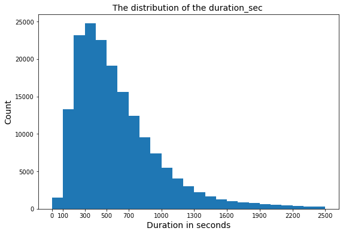

```python
#The distribution of the duration_sec
plt.figure(figsize = [9, 6])
bins = np.arange(0, 2500+100,100)
plt.hist(data = clean_df, x = 'duration_sec', bins = bins, color='#1f77b4');
plt.xticks([0,100,300,500,700,1000,1300,1600,1900,2200,2500]);
plt.xlabel('Duration in seconds', fontsize=14);
plt.ylabel('Count', fontsize=14);
plt.title("The distribution of the duration_sec ", fontsize=14);
```

> I used a histogram plot to show the distribution of the duration of the trips in seconds, but it was not clear

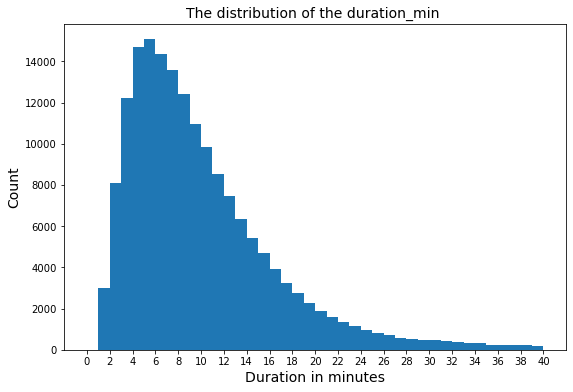

```python
#The distribution of the duration_min
clean_df['duration_min'] = clean_df['duration_sec']/60
plt.figure(figsize = [9, 6])
bins = np.arange(0, 40+1,1)
plt.hist(data = clean_df, x = 'duration_min',  bins = bins, color='#1f77b4');
plt.xticks([0,2,4,6,8,10,12,14,16,18,20,22,24,26,28,30,32,34,36,38,40]);
plt.xlabel('Duration in minutes', fontsize=14);
plt.ylabel('Count', fontsize=14);
plt.title("The distribution of the duration_min ", fontsize=14);
```

> because the previous histogram was not clear, I converted the duration of the trips from seconds to minutes, and I found that most trips take from 2 minutes to 12 minutes

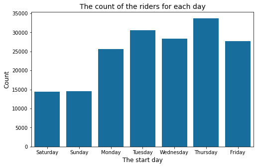

```python
#The count of the riders for each day
plt.figure(figsize = [8, 5]) ;
base_color = sb.color_palette('colorblind')[0]
sb.countplot(data = clean_df, x='start_day', color = base_color, order=['Saturday', 'Sunday', 'Monday', 'Tuesday', 'Wednesday', 'Thursday', 'Friday'])
plt.xlabel('The start day', fontsize=12);
plt.ylabel('Count', fontsize=12);
plt.title("The count of the riders for each day", fontsize=14);
```

> I used countplot to find the number of trips in each day of the week, and found that most trips happened during work days which are from monday to friday

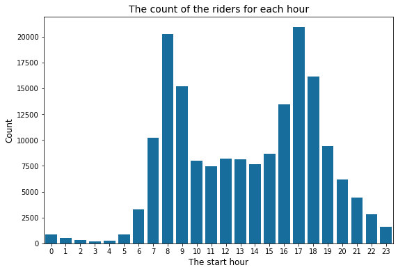

```python
#The count of the riders for each hour
#converting the starthour column to int so that it can be ordered easily
clean_df['start_hour'] = clean_df['start_hour'].astype(int)
plt.figure(figsize = [9, 6])
base_color = sb.color_palette('colorblind')[0]
sb.countplot(data = clean_df, x='start_hour', color = base_color);
plt.xlabel('The start hour', fontsize=12);
plt.ylabel('Count', fontsize=12);
plt.title("The count of the riders for each hour", fontsize=14);
```

> I used the count plot to show the number of trips in each hour of the day, and found that most common hours the people ride bikes in are 8am and 5pm

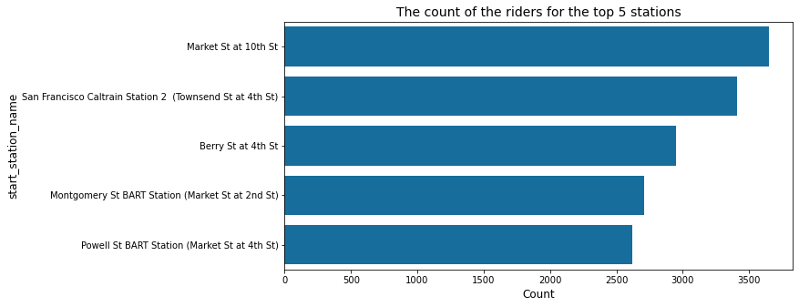

```python
#The count of the riders for the top 5 stations
plt.figure(figsize = [10, 5])
order = clean_df.start_station_name.value_counts().iloc[:5].index
base_color = sb.color_palette('colorblind')[0]
sb.countplot(data = clean_df, y='start_station_name', order = order, color= base_color);
plt.ylabel('start_station_name', fontsize=12);
plt.xlabel('Count', fontsize=12);
plt.title("The count of the riders for the top 5 stations", fontsize=14);
```

> I used countplot to find the top 5 stations that most people start with, and found that the station with the highest number is Market ST at 10th ST.

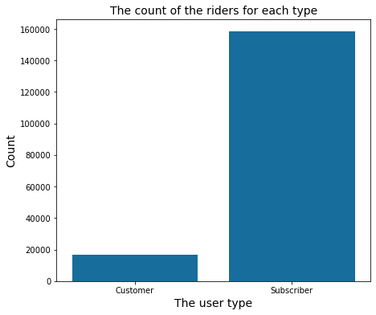

```python
#The count of the riders for each type
plt.figure(figsize = [7, 6])
base_color = sb.color_palette('colorblind')[0]
sb.countplot(data = clean_df, x='user_type', color = base_color);
plt.xlabel('The user type', fontsize=14);
plt.ylabel('Count', fontsize=14)
plt.title("The count of the riders for each type", fontsize=14);
```

> I used count plot to find the difference between the user's type, and found that the most riders are subscribers

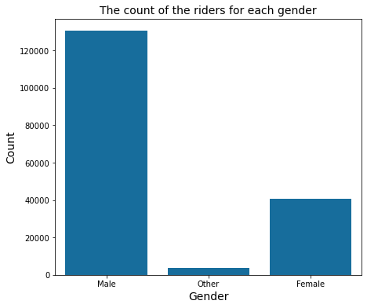

```python
#The count of the riders for each gender
plt.figure(figsize = [7, 6])
base_color = sb.color_palette('colorblind')[0]
sb.countplot(data = clean_df, x='member_gender', color = base_color);
plt.xlabel('Gender', fontsize=14);
plt.ylabel('Count', fontsize=14);
plt.title("The count of the riders for each gender", fontsize=14);
```

> > I used count plot to find the difference between the user's gender, and found that males riders are more than females

### Discuss the distribution(s) of your variable(s) of interest. Were there any unusual points? Did you need to perform any transformations?

> - The common ages of riders are from 25 to 40 years.
> - There are more males riders that females riders.
> - The number of subscribers were more bigger than the customers number.
> - the number of trips were at 8am and 5pm.
> - The number of trips on saturday and sunday were less than the rest of the week.
> - the most station the has users is Market st at 10th st

## Bivariate Exploration

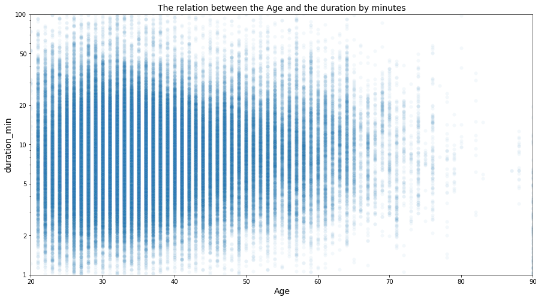

```python
#relation between the age and the duration per minute
plt.figure(figsize=(15,8));
g = sb.scatterplot(data = clean_df, x="Age", y="duration_min", alpha=0.05);
g.set(xlim=(20,90), yscale="log" , ylim=(1,100))
plt.yticks([1,2,5,10,20,50,100],[1,2,5,10,20,50,100]);
plt.xlabel('Age', fontsize=14);
plt.ylabel('duration_min', fontsize=14);
plt.title("The relation between the Age and the duration by minutes", fontsize=14);
```

> I used scatter plot to find the relation between the Age and the duration of the trips, and I noticed that from the age 20 to the age 40 the trips duartion is between 2 minutes to 40 minutes and it decreases by the increase in age

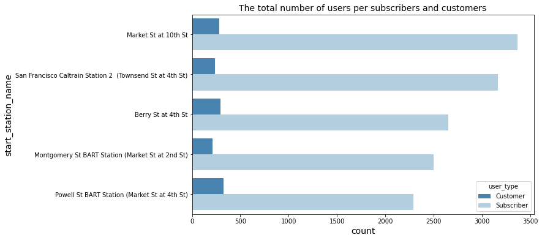

```python
#The total number of users per subscribers and customers
plt.figure(figsize = (10,6))
sb.countplot(data = clean_df, y='start_station_name', order = order, hue = 'user_type', palette="Blues_r");
plt.xlabel('count', fontsize=14);
plt.ylabel('start_station_name', fontsize=14);
plt.title('The total number of users per subscribers and customers', fontsize=14);
```

> I used count plot to compare the number of subscribers and the number of customers in each of the top 5 stations, and as expected the subscribers more than the customers in each station.

### Talk about some of the relationships you observed in this part of the investigation. How did the feature(s) of interest vary with other features in the dataset?

> I studied the relation between the age and the trips duration, and studied the number of customers and subscribers in the top 5 stations

### Did you observe any interesting relationships between the other features (not the main feature(s) of interest)?

> - by looking at the relation between Age and the trip duration_min I found that between the age of 20 and 40 the trips durations are between 3 to 30 minutes and it is decreasing by the increase in the age
> - by looking at the graph of the count per user type for the top 5 stations, I found that the subscirbers is more bigger than the customers in each station

## Multivariate Exploration

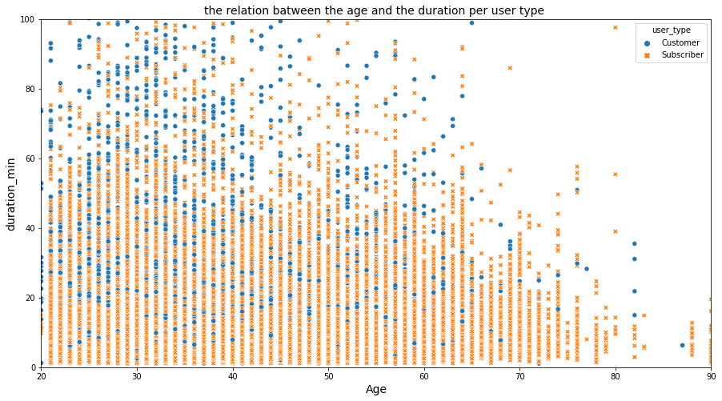

```python
#the relation between the age and duration_min per the user type
plt.figure(figsize=(15,8));
g = sb.scatterplot(data = clean_df, x="Age", y="duration_min", hue="user_type", style="user_type", );
g.set(xlim=(20,90), ylim=(0,100));
plt.xlabel('Age', fontsize=14);
plt.ylabel('duration_min', fontsize=14);
plt.title('the relation batween the age and the duration per user type ', fontsize=14);
```

> I used scatter to look at the relation between the Age and duration per minute for each user type, and to make it more clear I will seperate each one in a single graph.

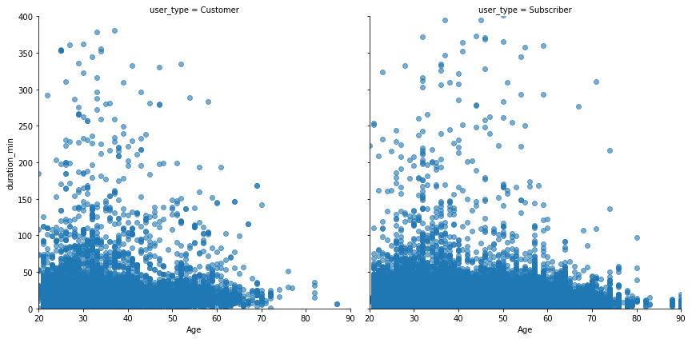

```python
#seperating each user type to clear see the difference
sb.FacetGrid(clean_df, col = "user_type", height = 6, xlim=(20,90), ylim=(0,400)).map(plt.scatter, "Age", "duration_min", alpha =0.6).add_legend();
```

### Talk about some of the relationships you observed in this part of the investigation. Were there features that strengthened each other in terms of looking at your feature(s) of interest?

> I studied the relation between the Age and Duration_min per the user type, and then seperated each user type in a chart to better see the difference between each of them

### Were there any interesting or surprising interactions between features?

> After looking at the relation between the age and the trip duration for each user type,I found that the trip duration doesn't differ from customer to subscriber, as for both types the duration decreases when the age increases. But found that the age of the subscribers is more than the age of the customers.